# TrabajoPersonal

Almudena Manzanal

24/1/2022

## Introducción

### Analizando dataset nycflights13:: flights

Vamos a analizar el siguiente dataset sobre vuelos de US y responder a una serie de preguntas.

```r
#install.packages("nycflights13")
flights <- nycflights13::flights
View(flights)
?flights
```

```
## starting httpd help server ... done
```

```r
library(tidyverse)
library(lubridate)
```

#### 1. Encuentra todos los vuelos que llegaron más de una hora tarde de lo previsto.

```r
Retrasos <- flights[flights$arr_delay > 60, ]

head(Retrasos)
```

```
## # A tibble: 6 x 19
##    year month   day dep_time sched_dep_time dep_delay arr_time sched_arr_time
##   <int> <int> <int>    <int>          <int>     <dbl>    <int>          <int>
## 1  2013     1     1      811            630       101     1047            830
## 2  2013     1     1      848           1835       853     1001           1950
## 3  2013     1     1      957            733       144     1056            853
## 4  2013     1     1     1114            900       134     1447           1222
## 5  2013     1     1     1120            944        96     1331           1213
## 6  2013     1     1     1255           1200        55     1451           1330
## # ... with 11 more variables: arr_delay <dbl>, carrier <chr>, flight <int>,
## #   tailnum <chr>, origin <chr>, dest <chr>, air_time <dbl>, distance <dbl>,
## #   hour <dbl>, minute <dbl>, time_hour <dttm>
```

#### 2. Encuentra todos los vuelos que volaron hacia San Francisco (aeropuertos SFO y OAK)

```r
San_Francisco <- flights[flights$dest == "OAK" | flights$dest == "SFO",]
SF <- filter(flights, dest == "OAK" | dest == "SFO")
head(San_Francisco)
```

```
## # A tibble: 6 x 19
##    year month   day dep_time sched_dep_time dep_delay arr_time sched_arr_time
##   <int> <int> <int>    <int>          <int>     <dbl>    <int>          <int>
## 1  2013     1     1      558            600        -2      923            937
## 2  2013     1     1      611            600        11      945            931
## 3  2013     1     1      655            700        -5     1037           1045
## 4  2013     1     1      729            730        -1     1049           1115
## 5  2013     1     1      734            737        -3     1047           1113
## 6  2013     1     1      745            745         0     1135           1125
## # ... with 11 more variables: arr_delay <dbl>, carrier <chr>, flight <int>,
## #   tailnum <chr>, origin <chr>, dest <chr>, air_time <dbl>, distance <dbl>,
## #   hour <dbl>, minute <dbl>, time_hour <dttm>
```

#### 3. Encuentra todos los vuelos operados por United American (UA) o por American Airlines (AA)

```r
UnitedAirlines <- filter(flights, carrier == "UA" | carrier == "AA" )
head(UnitedAirlines)
```

```
## # A tibble: 6 x 19
##    year month   day dep_time sched_dep_time dep_delay arr_time sched_arr_time
##   <int> <int> <int>    <int>          <int>     <dbl>    <int>          <int>
## 1  2013     1     1      517            515         2      830            819
## 2  2013     1     1      533            529         4      850            830
## 3  2013     1     1      542            540         2      923            850
## 4  2013     1     1      554            558        -4      740            728
## 5  2013     1     1      558            600        -2      753            745
## 6  2013     1     1      558            600        -2      924            917
## # ... with 11 more variables: arr_delay <dbl>, carrier <chr>, flight <int>,
## #   tailnum <chr>, origin <chr>, dest <chr>, air_time <dbl>, distance <dbl>,
## #   hour <dbl>, minute <dbl>, time_hour <dttm>
```

#### 4. Encuentra todos los vuelos que salieron los meses de primavera (Abril, Mayo y Junio)

```r
Primavera <- filter(flights, month == c(4, 5, 6))
head(Primavera)
```

```
## # A tibble: 6 x 19
##    year month   day dep_time sched_dep_time dep_delay arr_time sched_arr_time
##   <int> <int> <int>    <int>          <int>     <dbl>    <int>          <int>
## 1  2013     4     1      454            500        -6      636            640
## 2  2013     4     1      534            540        -6      833            850
## 3  2013     4     1      551            600        -9      748            659
## 4  2013     4     1      554            600        -6      752            805
## 5  2013     4     1      555            600        -5      846            910
## 6  2013     4     1      555            600        -5      913            925
## # ... with 11 more variables: arr_delay <dbl>, carrier <chr>, flight <int>,
## #   tailnum <chr>, origin <chr>, dest <chr>, air_time <dbl>, distance <dbl>,
## #   hour <dbl>, minute <dbl>, time_hour <dttm>
```

#### 5. Encuentra todos los vuelos que llegaron más de una hora tarde pero salieron con menos de una hora de retraso.

```r
DobleRetraso <- filter(flights, dep_delay < 60 & arr_time >60)
head(DobleRetraso)
```

```
## # A tibble: 6 x 19
##    year month   day dep_time sched_dep_time dep_delay arr_time sched_arr_time
##   <int> <int> <int>    <int>          <int>     <dbl>    <int>          <int>
## 1  2013     1     1      517            515         2      830            819
## 2  2013     1     1      533            529         4      850            830
## 3  2013     1     1      542            540         2      923            850
## 4  2013     1     1      544            545        -1     1004           1022
## 5  2013     1     1      554            600        -6      812            837
## 6  2013     1     1      554            558        -4      740            728
## # ... with 11 more variables: arr_delay <dbl>, carrier <chr>, flight <int>,
## #   tailnum <chr>, origin <chr>, dest <chr>, air_time <dbl>, distance <dbl>,
## #   hour <dbl>, minute <dbl>, time_hour <dttm>
```

#### 6. Encuentra todos los vuelos que salieron con más de una hora de retraso pero consiguieron llegar con menos de 30 minutos de retraso (el avión aceleró en el aire)

```r
RetrasoDep <- filter(flights, dep_delay > 60 & arr_delay < 30)
head(RetrasoDep)
```

```
## # A tibble: 6 x 19
##    year month   day dep_time sched_dep_time dep_delay arr_time sched_arr_time
##   <int> <int> <int>    <int>          <int>     <dbl>    <int>          <int>
## 1  2013     1     3     1850           1745        65     2148           2120
## 2  2013     1     3     1950           1845        65     2228           2227
## 3  2013     1     6     1019            900        79     1558           1530
## 4  2013     1     7     1543           1430        73     1758           1735
## 5  2013     1    12     1706           1600        66     1949           1927
## 6  2013     1    12     1953           1845        68     2154           2137
## # ... with 11 more variables: arr_delay <dbl>, carrier <chr>, flight <int>,
## #   tailnum <chr>, origin <chr>, dest <chr>, air_time <dbl>, distance <dbl>,
## #   hour <dbl>, minute <dbl>, time_hour <dttm>
```

#### 7. Encuentra todos los vuelos que salen entre medianoche y las 7 de la mañana (vuelos nocturnos).

```r
NocturnoReal <- filter(flights, dep_time <= 700 | dep_time == 2400)
NocturnoSched <- filter(flights, sched_dep_time <= 700 | sched_dep_time == 2400)
head(NocturnoSched)
```

```
## # A tibble: 6 x 19
##    year month   day dep_time sched_dep_time dep_delay arr_time sched_arr_time
##   <int> <int> <int>    <int>          <int>     <dbl>    <int>          <int>
## 1  2013     1     1      517            515         2      830            819
## 2  2013     1     1      533            529         4      850            830
## 3  2013     1     1      542            540         2      923            850
## 4  2013     1     1      544            545        -1     1004           1022
## 5  2013     1     1      554            600        -6      812            837
## 6  2013     1     1      554            558        -4      740            728
## # ... with 11 more variables: arr_delay <dbl>, carrier <chr>, flight <int>,
## #   tailnum <chr>, origin <chr>, dest <chr>, air_time <dbl>, distance <dbl>,
## #   hour <dbl>, minute <dbl>, time_hour <dttm>
```

#### 8. ¿Cuántos vuelos tienen un valor desconocido de dep_time?

```r
summary(is.na(flights$dep_time))
```

```
##    Mode   FALSE    TRUE
## logical  328521    8255
```

```r
#8255
```

#### 9. ¿Qué variables del dataset contienen valores desconocidos?

```r
summary(is.na(flights))
```

```
##     year           month            day           dep_time
##  Mode :logical   Mode :logical   Mode :logical   Mode :logical
##  FALSE:336776    FALSE:336776    FALSE:336776    FALSE:328521
##                                                  TRUE :8255
##  sched_dep_time  dep_delay        arr_time       sched_arr_time
##  Mode :logical   Mode :logical   Mode :logical   Mode :logical
##  FALSE:336776    FALSE:328521    FALSE:328063    FALSE:336776
##                  TRUE :8255      TRUE :8713
##  arr_delay        carrier          flight         tailnum
##  Mode :logical   Mode :logical   Mode :logical   Mode :logical
##  FALSE:327346    FALSE:336776    FALSE:336776    FALSE:334264
##  TRUE :9430                                      TRUE :2512
##    origin           dest          air_time        distance
##  Mode :logical   Mode :logical   Mode :logical   Mode :logical
##  FALSE:336776    FALSE:336776    FALSE:327346    FALSE:336776
##                                  TRUE :9430
##     hour           minute        time_hour
##  Mode :logical   Mode :logical   Mode :logical
##  FALSE:336776    FALSE:336776    FALSE:336776
##
```

```r
# Son dep_time, dep_delay, arr_time, arr_delay, tailnum, air_time
```

#### 10. Ordena los vuelos de flights para encontrar los vuelos más retrasados en la salida. ¿Qué vuelos fueron los que salieron los primeros antes de lo previsto?

```r
arrange(flights, dep_delay)
```

```
## # A tibble: 336,776 x 19
##     year month   day dep_time sched_dep_time dep_delay arr_time sched_arr_time
##    <int> <int> <int>    <int>          <int>     <dbl>    <int>          <int>
##  1  2013    12     7     2040           2123       -43       40           2352
##  2  2013     2     3     2022           2055       -33     2240           2338
##  3  2013    11    10     1408           1440       -32     1549           1559
##  4  2013     1    11     1900           1930       -30     2233           2243
##  5  2013     1    29     1703           1730       -27     1947           1957
##  6  2013     8     9      729            755       -26     1002            955
##  7  2013    10    23     1907           1932       -25     2143           2143
##  8  2013     3    30     2030           2055       -25     2213           2250
##  9  2013     3     2     1431           1455       -24     1601           1631
## 10  2013     5     5      934            958       -24     1225           1309
## # ... with 336,766 more rows, and 11 more variables: arr_delay <dbl>,
## #   carrier <chr>, flight <int>, tailnum <chr>, origin <chr>, dest <chr>,
## #   air_time <dbl>, distance <dbl>, hour <dbl>, minute <dbl>, time_hour <dttm>
```

```r
arrange(flights, desc(dep_delay))
```

```
## # A tibble: 336,776 x 19
##     year month   day dep_time sched_dep_time dep_delay arr_time sched_arr_time
##    <int> <int> <int>    <int>          <int>     <dbl>    <int>          <int>
##  1  2013     1     9      641            900      1301     1242           1530
##  2  2013     6    15     1432           1935      1137     1607           2120
##  3  2013     1    10     1121           1635      1126     1239           1810
##  4  2013     9    20     1139           1845      1014     1457           2210
##  5  2013     7    22      845           1600      1005     1044           1815
##  6  2013     4    10     1100           1900       960     1342           2211
##  7  2013     3    17     2321            810       911      135           1020
##  8  2013     6    27      959           1900       899     1236           2226
##  9  2013     7    22     2257            759       898      121           1026
## 10  2013    12     5      756           1700       896     1058           2020
## # ... with 336,766 more rows, and 11 more variables: arr_delay <dbl>,
## #   carrier <chr>, flight <int>, tailnum <chr>, origin <chr>, dest <chr>,
## #   air_time <dbl>, distance <dbl>, hour <dbl>, minute <dbl>, time_hour <dttm>
```

#### 11. Ordena los vuelos de flights para encontrar los vuelos más rápidos. Usa el concepto de rapidez que consideres.

```r
flights$vel <- flights$distance / flights$air_time
arrange(flights, desc(vel))
```

```
## # A tibble: 336,776 x 20
##     year month   day dep_time sched_dep_time dep_delay arr_time sched_arr_time
##    <int> <int> <int>    <int>          <int>     <dbl>    <int>          <int>
##  1  2013     5    25     1709           1700         9     1923           1937
##  2  2013     7     2     1558           1513        45     1745           1719
##  3  2013     5    13     2040           2025        15     2225           2226
##  4  2013     3    23     1914           1910         4     2045           2043
##  5  2013     1    12     1559           1600        -1     1849           1917
##  6  2013    11    17      650            655        -5     1059           1150
##  7  2013     2    21     2355           2358        -3      412            438
##  8  2013    11    17      759            800        -1     1212           1255
##  9  2013    11    16     2003           1925        38       17             36
## 10  2013    11    16     2349           2359       -10      402            440
## # ... with 336,766 more rows, and 12 more variables: arr_delay <dbl>,
## #   carrier <chr>, flight <int>, tailnum <chr>, origin <chr>, dest <chr>,
## #   air_time <dbl>, distance <dbl>, hour <dbl>, minute <dbl>, time_hour <dttm>,
## #   vel <dbl>
```

#### 12. ¿Qué vuelos tienen los trayectos más largos?

```r
  flights %>%
  group_by(origin, dest) %>%
  summarise(
      distance = mean(distance)
  ) %>%
  arrange(desc(distance))
```

```
## # A tibble: 224 x 3
## # Groups:   origin [3]
##    origin dest  distance
##    <chr>  <chr>    <dbl>
##  1 JFK    HNL       4983
##  2 EWR    HNL       4963
##  3 EWR    ANC       3370
##  4 JFK    SFO       2586
##  5 JFK    OAK       2576
##  6 JFK    SJC       2569
##  7 EWR    SFO       2565
##  8 JFK    SMF       2521
##  9 JFK    LAX       2475
## 10 JFK    BUR       2465
## # ... with 214 more rows
```

#### 13. ¿Qué vuelos tienen los trayectos más cortos?

```r
  flights %>%
  group_by(origin, dest) %>%
  summarise(
      distance = mean(distance)
  ) %>%
  arrange(distance)
```

```
## # A tibble: 224 x 3
## # Groups:   origin [3]
##    origin dest  distance
##    <chr>  <chr>    <dbl>
##  1 EWR    LGA         17
##  2 EWR    PHL         80
##  3 JFK    PHL         94
##  4 LGA    PHL         96
##  5 EWR    BDL        116
##  6 EWR    ALB        143
##  7 EWR    PVD        160
##  8 EWR    BWI        169
##  9 JFK    MVY        173
## 10 JFK    BWI        184
## # ... with 214 more rows
```

#### 14. El dataset de vuelos tiene dos variables, dep_time y sched_dep_time muy útiles pero difíciles de usar por cómo vienen dadas al no ser variables continuas. Fíjate que cuando pone 559, se refiere a que el vuelo salió a las 5:59… Convierte este dato en otro más útil que represente el número de minutos que pasan desde media noche

```r
datetime <- function(year, month, day, time)
  {
    make_datetime(year, month, day, time %/% 100, time %% 100)
  }

flights_dt <-
  flights %>%
      mutate(
          dep_time = datetime(year, month, day, dep_time),
          sched_dep_time = datetime(year, month, day, sched_dep_time)
             )
flights$sched_dep_time <- hour(flights_dt$sched_dep_time)*60 + minute(flights_dt$sched_dep_time)

flights$dep_time <- hour(flights_dt$dep_time)*60 + minute(flights_dt$dep_time)
```

#### 15. Compara los valores de dep_time, sched_dep_time y dep_delay. ¿Cómo deberían relacionarse estos tres números? Compruébalo y haz las correcciones numéricas que necesitas.

```r
#Se deben restar el tiempo programado al tiempo real de salida y se dan en minutos:
dep <- as.numeric(flights_dt$dep_time - flights_dt$sched_dep_time) / 60
```

#### 16. Investiga si existe algún patrón del número de vuelos que se cancelan cada día.

```r
cancelled_per_day <-
  flights %>%
  mutate(cancelled = (is.na(arr_delay) | is.na(dep_delay))) %>%
  group_by(year, month, day) %>%
  summarise(
    cancelled_num = sum(cancelled),
    flights_num = n(),
  )
```

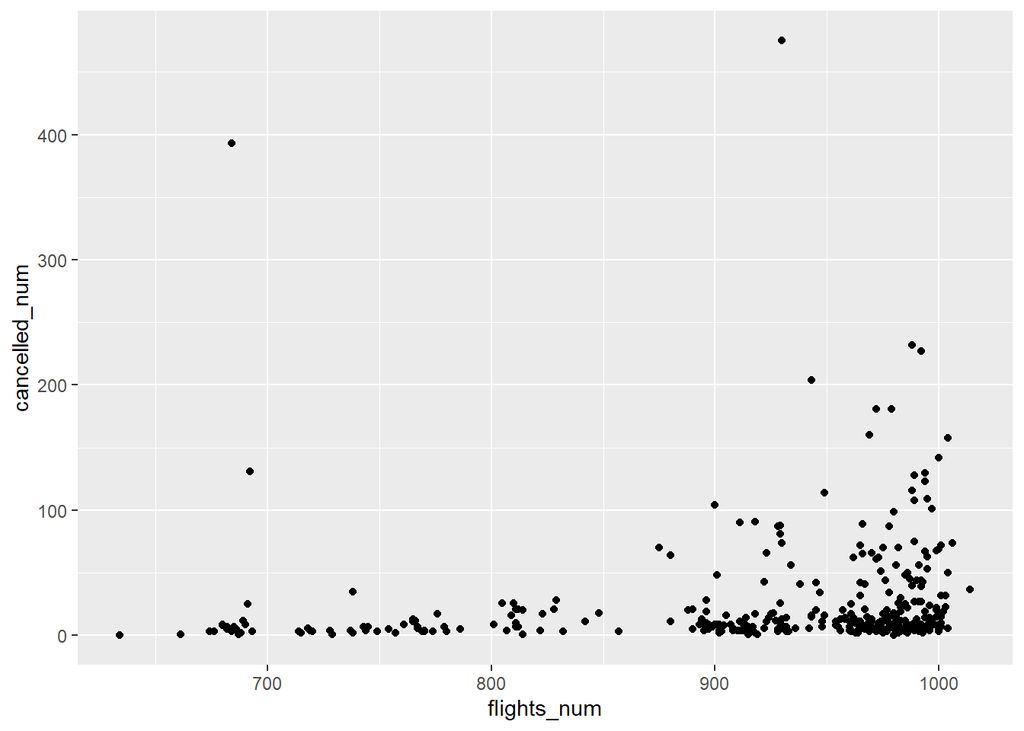

```r
ggplot(cancelled_per_day) +
  geom_point(aes(x = flights_num, y = cancelled_num))
```

#### 17. Investiga si la proporción de vuelos cancelados está relacionada con el retraso promedio por día en los vuelos.

```r
cancelled_and_delays <-
  flights %>%
  mutate(cancelled = (is.na(arr_delay) | is.na(dep_delay))) %>%
  group_by(year, month, day) %>%
  summarise(
    cancelled_prop = mean(cancelled),
    avg_dep_delay = mean(dep_delay, na.rm = TRUE),
    avg_arr_delay = mean(arr_delay, na.rm = TRUE)
  ) %>%
  ungroup()
```

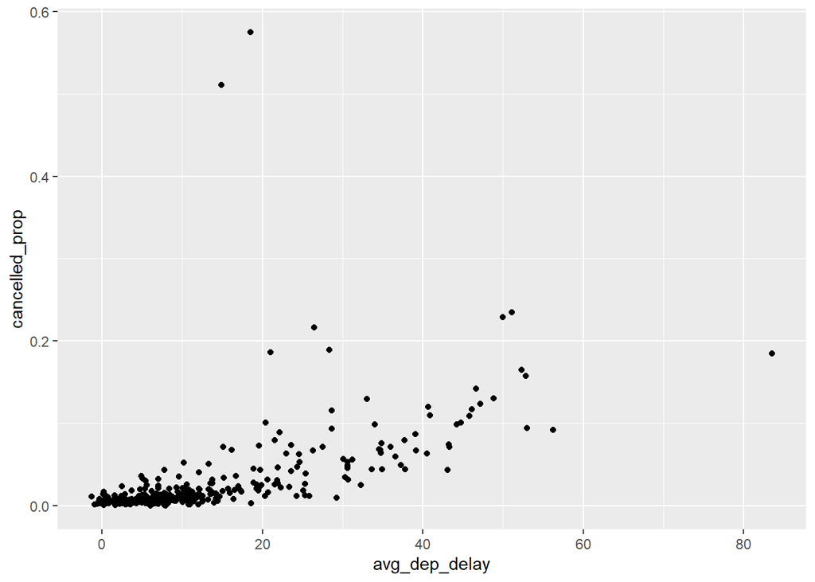

```r
ggplot(cancelled_and_delays) +
  geom_point(aes(x = avg_dep_delay, y = cancelled_prop))
```

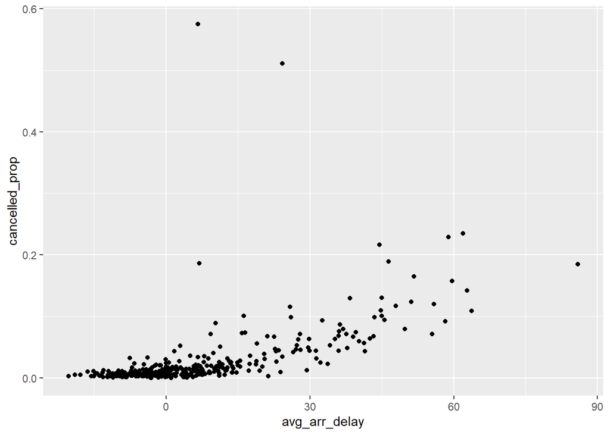

```r
ggplot(cancelled_and_delays) +
  geom_point(aes(x = avg_arr_delay, y = cancelled_prop))
```

#### 18. Investiga si la proporción de vuelos cancelados está relacionada con el retraso promedio por aeropuerto en los vuelos.

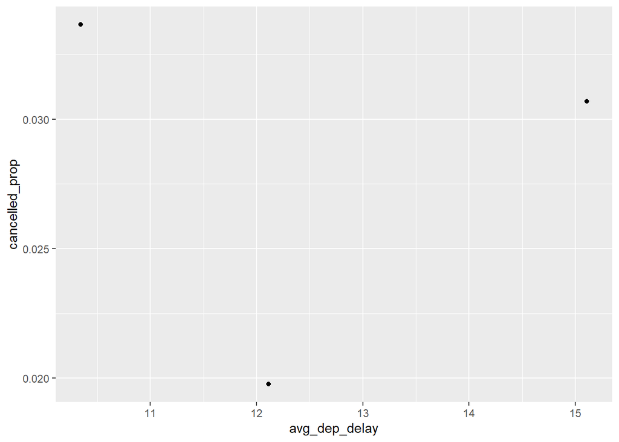

```r
cancelled_and_origin <-
  flights %>%
  mutate(cancelled = (is.na(arr_delay) | is.na(dep_delay))) %>%
  group_by(origin) %>%
  summarise(
    cancelled_prop = mean(cancelled),
    avg_dep_delay = mean(dep_delay, na.rm = TRUE)
  ) %>%
  ungroup()

cancelled_and_dest <-
  flights %>%
  mutate(cancelled = (is.na(arr_delay) | is.na(dep_delay))) %>%
  group_by(dest) %>%
  summarise(
    cancelled_prop = mean(cancelled),
    avg_arr_delay = mean(arr_delay, na.rm = TRUE)
  ) %>%
  ungroup()

ggplot(cancelled_and_origin) +
  geom_point(aes(x = avg_dep_delay, y = cancelled_prop))
```

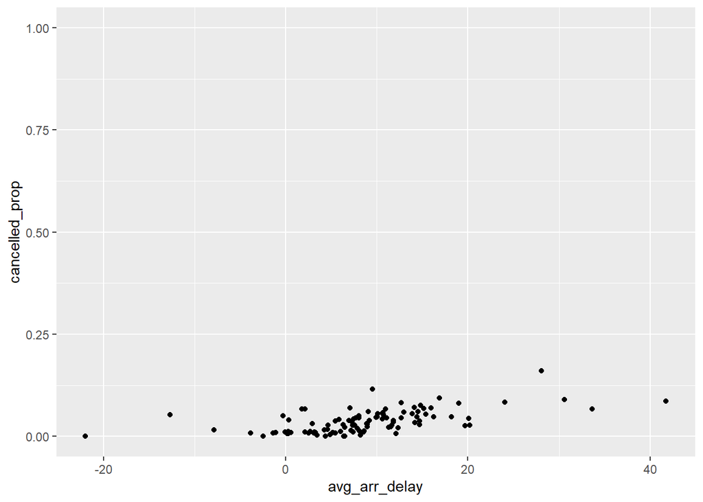

```r
ggplot(cancelled_and_dest) +
  geom_point(aes(x = avg_arr_delay, y = cancelled_prop))
```

#### 19. ¿Qué compañía aérea sufre los peores retrasos?

```r
delays_carrier <-
  flights %>%
  group_by(carrier) %>%
  summarise(
    avg_dep_delay = mean(dep_delay, na.rm = TRUE),
    avg_arr_delay = mean(arr_delay, na.rm = TRUE)
  ) %>%
  ungroup()

arrange(delays_carrier, desc(avg_dep_delay))
```

```
## # A tibble: 16 x 3
##    carrier avg_dep_delay avg_arr_delay
##    <chr>           <dbl>         <dbl>
##  1 F9              20.2         21.9
##  2 EV              20.0         15.8
##  3 YV              19.0         15.6
##  4 FL              18.7         20.1
##  5 WN              17.7          9.65
##  6 9E              16.7          7.38
##  7 B6              13.0          9.46
##  8 VX              12.9          1.76
##  9 OO              12.6         11.9
## 10 UA              12.1          3.56
## 11 MQ              10.6         10.8
## 12 DL               9.26         1.64
## 13 AA               8.59         0.364
## 14 AS               5.80        -9.93
## 15 HA               4.90        -6.92
## 16 US               3.78         2.13
```

```r
arrange(delays_carrier, desc(avg_arr_delay))
```

```
## # A tibble: 16 x 3
##    carrier avg_dep_delay avg_arr_delay
##    <chr>           <dbl>         <dbl>
##  1 F9              20.2         21.9
##  2 FL              18.7         20.1
##  3 EV              20.0         15.8
##  4 YV              19.0         15.6
##  5 OO              12.6         11.9
##  6 MQ              10.6         10.8
##  7 WN              17.7          9.65
##  8 B6              13.0          9.46
##  9 9E              16.7          7.38
## 10 UA              12.1          3.56
## 11 US               3.78         2.13
## 12 VX              12.9          1.76
## 13 DL               9.26         1.64
## 14 AA               8.59         0.364
## 15 HA               4.90        -6.92
## 16 AS               5.80        -9.93
```

#### 20. Queremos saber qué hora del día nos conviene volar si queremos evitar los retrasos en la salida.

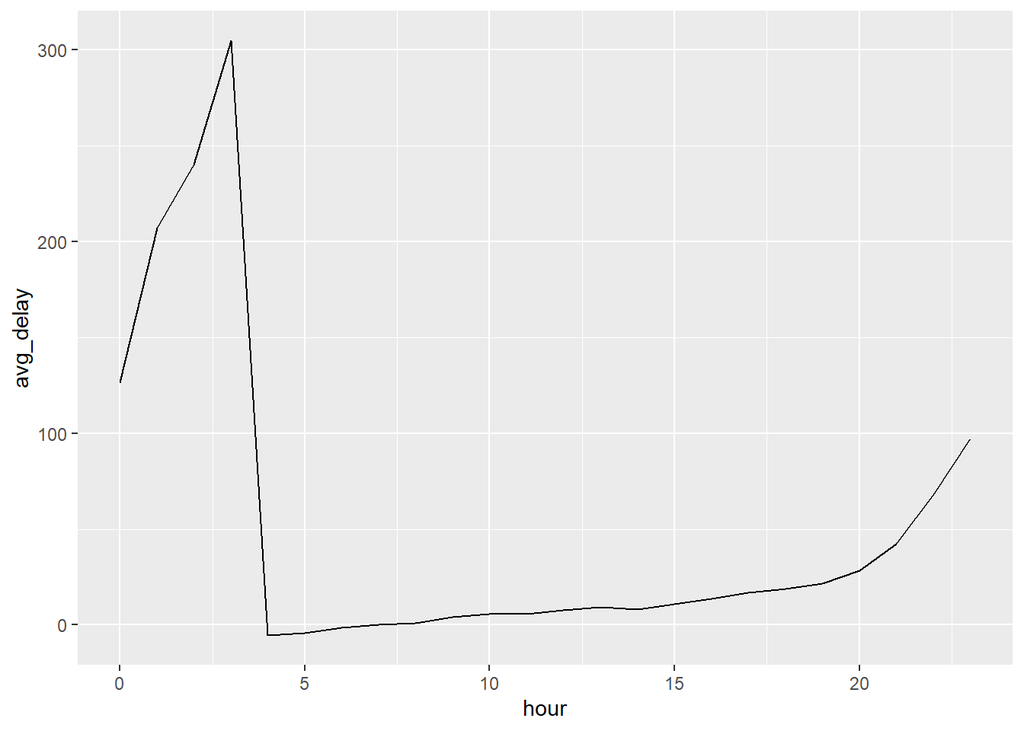

```r
delay_hour <-
flights_dt %>%
  mutate(hour = hour(dep_time)) %>%
  group_by(hour) %>%
  summarise(
    avg_delay = mean(dep_delay, na.rm = TRUE),
    n = n())


  ggplot(delay_hour) +
    geom_line(aes(hour, avg_delay))
```

#### 21. Queremos saber qué día de la semana nos conviene volar si queremos evitar los retrasos en la salida

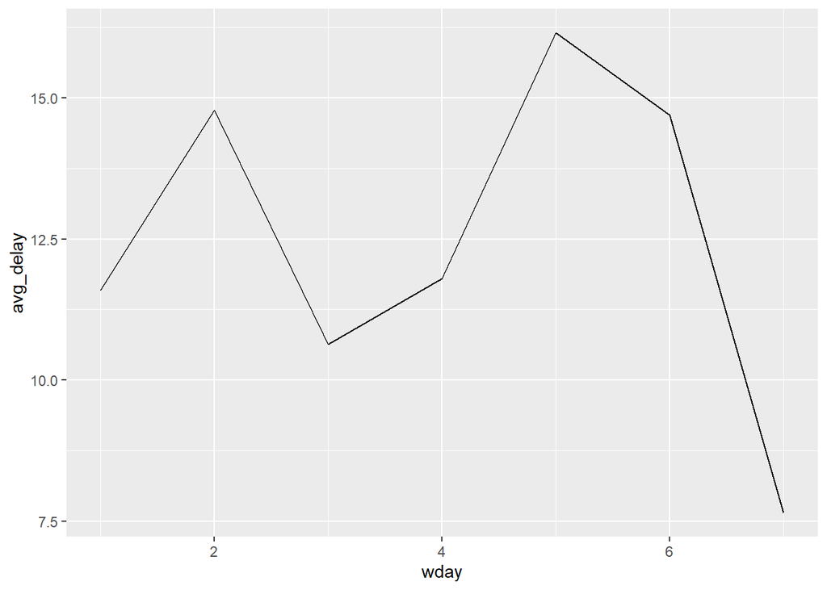

```r
delay_wday <-
flights_dt %>%
  mutate(wday = wday(sched_dep_time)) %>%
  group_by(wday) %>%
  summarise(
    avg_delay = mean(dep_delay, na.rm = TRUE),
    n = n())


  ggplot(delay_wday) +
    geom_line(aes(wday, avg_delay))
```

#### 22. Para cada destino, calcula el total de minutos de retraso acumulado.

```r
delay_dest <-
  flights %>%
  filter(arr_delay > 0) %>%
  group_by(dest) %>%
  summarise(
    sum_delay = sum(arr_delay, na.rm = TRUE)
    )
```

#### 23. Para cada uno de ellos, calcula la proporción del total de retraso para dicho destino.

```r
delayprop_dest <-
  flights %>%
  filter(arr_delay > 0) %>%
  group_by(dest) %>%
  summarise(
    sum_delay = sum(arr_delay, na.rm = TRUE),
    delay_prop = mean(arr_delay, na.rm =TRUE)
    )
```

#### 24. Es hora de aplicar todo lo que hemos aprendido para visualizar mejor los tiempos de salida para vuelos cancelados vs los no cancelados. Recuerda bien qué tipo de dato tenemos en cada caso. ¿Qué deduces acerca de los retrasos según la hora del día a la que está programada el vuelo de salida?

```r
flights_dt$cancelled <-  ifelse((is.na(flights_dt$arr_delay) | is.na(flights_dt$dep_delay)) == TRUE, print(TRUE), print(FALSE))
```

```
## [1] TRUE
## [1] FALSE
```

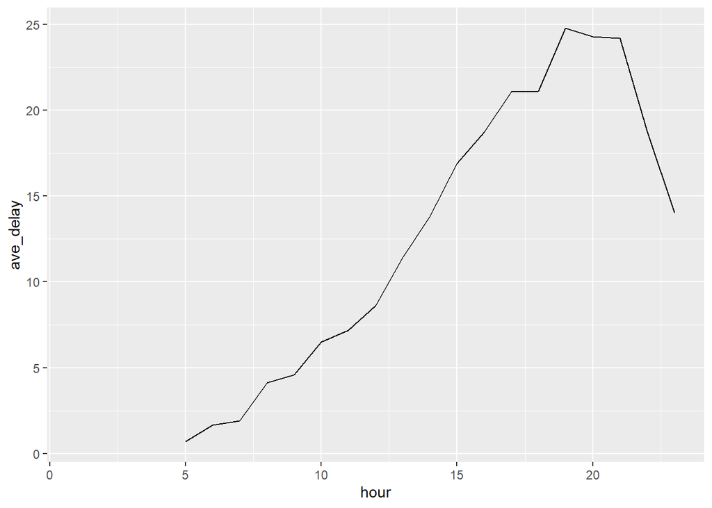

```r
cancelled <- flights_dt %>%
  filter(cancelled == TRUE)

not_cancelled <- flights_dt %>%
  filter(!is.na(dep_delay), !is.na(arr_delay))

sched_dep2 <- flights_dt %>%
  mutate(hour = hour(sched_dep_time)) %>%
  group_by(hour) %>%
  summarise(
    ave_delay = mean(dep_delay, na.rm = TRUE),
    n = n()
  )

ggplot(sched_dep2, aes(hour, ave_delay)) +
  geom_line()
```

```r
#Muchos mas retrasos a ultimas horas del dia.
```

#### 25. Subir la carpeta a github y facilitar la url.

```r
# https://github.com/amanzgdl/TrabajoPersonal_AlmudenaManzanal
```